# Eksplorasi Data Airbnb

# Introduction

Airbnb, Inc (Airbnb) adalah *marketplace* untuk memesan penginapan/*homestay* atau paket liburan, secara online melalui aplikasi. Pengguna cukup mengunduh aplikasi Airbnb melalui Google Play/Apple Store, kemudian pengguna akan mencari lokasi properti penginapan, berikut tanggal menginap. Aplikasi kemudian akan menampilkan daftar properti yang tersedia pada lokasi dan tanggal tersebut. Pengguna kemudian membayarkan *fee* kepada Airbnb, untuk diteruskan kepada pemilik properti. Dalam hal ini, perusahaan Airbnb tidak memiliki aset properti yang ditawarkan, namun Airbnb bertindak sebagai perantara (antara pemilik properti [host] dan pengguna). Airbnb berkantor pusat di San Fransisco, California, Amerika Serikat.

Dari properti yang tersedia di Airbnb, apakah faktor penentu harga properti di Airbnb?

# Methodology

## Data Understanding

SteveZheng (Steve Zheng), merupakan kontributor di Kaggle.com yang mengunggah dataset [“Airbnb price prediction”](https://www.kaggle.com/stevezhenghp/airbnb-price-prediction). Dataset merupakan data properti Airbnb yang ada di Amerika Serikat. Dataset terdiri dari **74111** baris data, dengan **29** fitur

Deskripsi fitur-fitur yang tersedia (menurut interpretasi penulis, dikarenakan tidak adanya dokumentasi resmi dari kontributor) dan yang digunakan, adalah sebagai berikut :

| No | Feature | Description | Fitur digunakan? | Response/Predictor |
| --- | --- | --- | --- | --- |
| 1 | id | Nomor ID properti | Tidak | - |
| 2 | log_price | Harga sewa properti (dalam bentuk log) | Ya | Response |
| 3 | property_type | Jenis properti (contoh : apartemen, rumah, dsb) | Ya | Predictor |
| 4 | room_type | Jenis kamar yang disewakan. Contoh : 1) entire home/apt –> seluruh rumah/apartemen, 2) private room –> kamar pribadi yang disewakan, 3) Shared room –> kamar yang dibagi dengan pengguna lain) | Ya | Predictor |
| 5 | amenities | Kelengkapan lain dari properti | Tidak | - |
| 6 | accomodates | Jumlah kapasitas orang yang dapat menginap dalam properti yang disewakan | Ya | Predictor |
| 7 | bathrooms | Jumlah kamar mandi tersedia | Ya | Predictor |
| 8 | bed_type | Jenis kasur yang disediakan : Real Bed, Futon, Pull-out Sofa, Couch atau Airbed | Ya | Predictor |
| 9 | cancellation_policy | Persyaratan pembatalan | Ya | Predictor |
| 10 | cleaning_fee | Ada atau tidaknya biaya pembersihan kamar | Ya | Predictor |
| 11 | city | Kota letak properti berada | Ya | Predictor |
| 12 | description | Deskripsi properti | Tidak | - |
| 13 | first_review | Tanggal review pertama | Ya | Predictor |
| 14 | host_has_profile_pic | Penanda apakah *host* menampilkan foto profil pada akun Airbnb | Tidak | - |
| 15 | host_identity_verified | Penanda apakah *host* telah diverifikasi oleh Airbnb | Tidak | - |
| 16 | host_response_rate | Kecepatan *host* dalam merespons setiap pertanyaan yang masuk | Tidak | - |
| 17 | host_since | Tanggal *host* mulai memasukkan propertinya pada Airbnb | Tidak | - |
| 18 | instant_bookable | Penanda apakah properti dapat langsung di book tanpa perlu adanya konfirmasi dari *host* | Ya | Predictor |
| 19 | last_review | Tanggal review terakhir | Tidak | - |
| 20 | latitude | *Latitude* lokasi properti | Ya | Predictor |
| 21 | longitude | *Longitude* lokasi properti | Ya | Predictor |
| 22 | name | Nama properti | Tidak | - |
| 23 | neighbourhood | nama wilayah | Tidak | - |
| 24 | number_of_reviews | jumlah review yang diberikan | Tidak | - |
| 25 | review_scores_rating | Skor review | Ya | Predictor |
| 26 | thumbnail_url | URL link gambar dari properti | Tidak | - |
| 27 | zipcode | Kodepos properti | Tidak | - |
| 28 | bedrooms | Banyak kamar tidur | Ya | Predictor |
| 29 | beds | Banyak tempat tidur yang disediakan | Ya | Predictor |

Adapun ringkasan dari nilai pada setiap feature adalah sebagai berikut :

```r
library(tidyverse)
airBNB<-read_csv("train.csv")
summary(airBNB)
```

```
       id             log_price     property_type       room_type
 Min.   :     344   Min.   :0.000   Length:74111       Length:74111
 1st Qu.: 6261964   1st Qu.:4.317   Class :character   Class :character
 Median :12254147   Median :4.710   Mode  :character   Mode  :character
 Mean   :11266617   Mean   :4.782
 3rd Qu.:16402260   3rd Qu.:5.220
 Max.   :21230903   Max.   :7.600

  amenities          accommodates      bathrooms       bed_type
 Length:74111       Min.   : 1.000   Min.   :0.000   Length:74111
 Class :character   1st Qu.: 2.000   1st Qu.:1.000   Class :character
 Mode  :character   Median : 2.000   Median :1.000   Mode  :character
                    Mean   : 3.155   Mean   :1.235
                    3rd Qu.: 4.000   3rd Qu.:1.000
                    Max.   :16.000   Max.   :8.000
                                     NA's   :200
 cancellation_policy cleaning_fee        city           description
 Length:74111        Mode :logical   Length:74111       Length:74111
 Class :character    FALSE:19708     Class :character   Class :character
 Mode  :character    TRUE :54403     Mode  :character   Mode  :character




  first_review        host_has_profile_pic host_identity_verified
 Min.   :2008-11-17   Mode :logical        Mode :logical
 1st Qu.:2015-06-28   FALSE:226            FALSE:24175
 Median :2016-05-25   TRUE :73697          TRUE :49748
 Mean   :2016-01-14   NA's :188            NA's :188
 3rd Qu.:2017-01-02
 Max.   :2017-10-05
 NA's   :15864
 host_response_rate   host_since         instant_bookable  last_review
 Length:74111       Min.   :2008-03-03   Mode :logical    Min.   :2009-01-21
 Class :character   1st Qu.:2013-04-21   FALSE:54660      1st Qu.:2017-01-09
 Mode  :character   Median :2014-09-28   TRUE :19451      Median :2017-04-28
                    Mean   :2014-07-21                    Mean   :2017-03-14
                    3rd Qu.:2015-12-22                    3rd Qu.:2017-09-08
                    Max.   :2017-10-04                    Max.   :2017-10-05
                    NA's   :188                           NA's   :15827
```

[output cut: 9 more lines]

```
 Min.   :  0.0     Min.   : 20.00       Length:74111       Length:74111
 1st Qu.:  1.0     1st Qu.: 92.00       Class :character   Class :character
 Median :  6.0     Median : 96.00       Mode  :character   Mode  :character
 Mean   : 20.9     Mean   : 94.07
 3rd Qu.: 23.0     3rd Qu.:100.00
 Max.   :605.0     Max.   :100.00
                   NA's   :16722
    bedrooms           beds
 Min.   : 0.000   Min.   : 0.000
 1st Qu.: 1.000   1st Qu.: 1.000
 Median : 1.000   Median : 1.000
 Mean   : 1.266   Mean   : 1.711
 3rd Qu.: 1.000   3rd Qu.: 2.000
 Max.   :10.000   Max.   :18.000
 NA's   :91       NA's   :131
```

Dari summary diatas, diketahui bahwa terdapat beberapa feature yang memiliki nilai NA. Fitur review_scores_rating memiliki NA yang cukup tinggi. Hal ini diakibatkan karena properti tersebut belum memiliki rating. Diduga bahwa properti tersebut adalah properti baru. Oleh karena itu, dataset akan dibagi menjadi 2 *cluster*, yakni dataset untuk properti baru (belum pernah dipesan) dan properti lama (pernah dipesan). Adapun *instance* yang memiliki nilai NA untuk setiap cluster nya akan diabaikan dan tidak digunakan untuk proses pemodelan.

Dari data terdapat *instance* yang nilai log_price nya adalah 0. Terkait hal ini, instance tersebut tidak akan dimasukkan kedalam proses modelling

```r
airBNB<-subset(airBNB,log_price>0)
```

Korelasi data numerik dapat disajikan sebagai berikut :

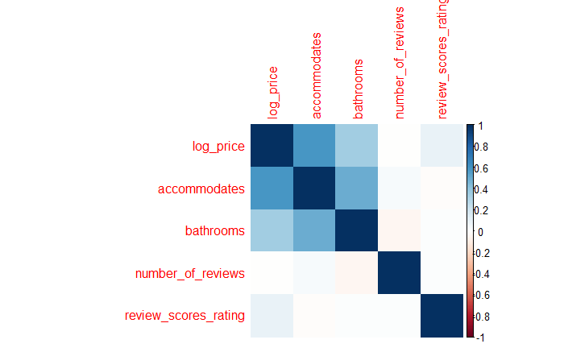

Secara garis besar, data yang digunakan memiliki sebaran harga sebagai berikut :

```r
ggplot(airBNB,aes(log_price))+geom_histogram(bins=20)+labs(title = "Distribusi Harga Properti", x="Harga (dalam fungsi log)", y="Jumlah Properti")

ggplot(airBNB,aes(x=NULL, y=log_price))+geom_boxplot()+labs(title = "Distribusi Harga Properti", y="Harga (dalam fungsi log)",x=NULL)
```

[output not shown]

Dari gambar terlihat bahwa harga mayoritas berada pada rentang 4.3 - 5.2

Jumlah properti berdasarkan jenis nya, dapat ditampilkan dalam grafik sebagai berikut :

```r
ggplot(airBNB,aes(property_type))+geom_bar()+theme(axis.text.x = element_text(angle = 90))+labs(title = "Jumlah Properti berdasarkan Jenis Properti", y="Jenis Properti",x="Jumlah Properti")+ scale_x_discrete(limits=c(unique(airBNB$property_type)))
```

[output not shown]

```r
ggplot(airBNB,aes(accommodates))+geom_bar()+theme(axis.text.x = element_text(angle = 90))+labs(title = "Distribusi Jumlah Properti berdasarkan Jumlah Penginap yang bisa Ditampung", y="Jumlah Properti",x="Jumlah Penginap") + scale_x_discrete(limits=c(1:1:16))
```

[output not shown]

Dari grafik tersebut, mayoritas properti dapat menampung maksimal 2 penginap. Terdapat beberapa properti yang dapat menampung sampai 16 penginap.

Berdasarkan jumlah kamar mandi yang tersedia pada setiap properti, dapat digambarkan dalam grafik distribusi sebagai berikut :

```r
ggplot(airBNB,aes(bathrooms))+geom_bar()+theme(axis.text.x = element_text(angle = 90))+labs(title = "Distribusi Jumlah Properti berdasarkan Jumlah Kamar Mandi", y="Jumlah Properti",x="Jumlah Kamar Mandi") + scale_x_discrete(limits=seq(from = 0, to = 8, by = 0.5))
```

[output not shown]

Berdasarkan kota, distribusi properti dapat digambarkan sebagai berikut :

```r
ggplot(airBNB,aes(city))+geom_bar()+theme(axis.text.x = element_text(angle = 90))+labs(title = "Distribusi Jumlah Properti berdasarkan Kota", y="Jumlah Properti",x="Kota")
```

[output not shown]

```r
library(mapdata)
library(ggplot2)
library(rnaturalearth)
library(rnaturalearthdata)
library(rgeos)
library(maps)
library(sf)
library(tools)

world <- ne_countries(scale = "medium", returnclass = "sf")
sites <- data.frame(longitude = airBNB$longitude,
                    latitude = airBNB$latitude
                    )
states <- st_as_sf(map("state", plot = FALSE, fill = TRUE))
states <- cbind(states, st_coordinates(st_centroid(states)))


ggplot(data = world) +
  geom_sf() +
  geom_sf(data = states, fill = NA) +
  geom_text(data = states, aes(X, Y, label = ID), size = 2) +
  geom_point(data = sites, aes(x = longitude, y = latitude), size = 3,
             shape = 16, fill = "red") +
  coord_sf(xlim = c(-121, -70), ylim = c(25, 50), expand = FALSE)+
  labs(title = "Sebaran Properti Airbnb pada Peta AS")
```

[output not shown]

## Metode Pemodelan

Fungsi `lm()` di R akan otomatis mengubah fitur yang bertipe kategorikal menjadi *dummy variable*

# Result

## Cluster I : Properti Lama

Tahap pertama dilakukan *subsetting* terhadap dataset yang memiliki `review_scores_rating` lebih dari 0 (tidak NA). Data tersebut disimpan dalam variabel bernama `subset_airBNB_lama`

```r
subset_airBNB_lama<-subset(airBNB,review_scores_rating>=0)
```

Pemodelan dibuat dengan memanggil fungsi `lm()` terhadap subset data properti lama

```r
linearModel_airBNB_lama<-lm(log_price ~ property_type+room_type+accommodates+bathrooms+
                  bed_type+cancellation_policy+cleaning_fee+city+instant_bookable+
                  latitude+longitude+review_scores_rating+bedrooms+beds, data=subset_airBNB_lama)
summary(linearModel_airBNB_lama)
```

[output not shown]

```r
qqnorm(linearModel_airBNB_lama[["residuals"]])
qqline(linearModel_airBNB_lama[["residuals"]])
```

[output not shown]

```r
library(mlbench)
library(caret)
library(MASS)

fs_both<-stepAIC(linearModel_airBNB_lama,direction = "both")
```

[output not shown]

```r
linearModel_airBNB_lama_fs<-lm(formula=fs_both[["terms"]],data=subset_airBNB_lama)
summary(linearModel_airBNB_lama_fs)
```

[output not shown]

```r
qqnorm(linearModel_airBNB_lama_fs[["residuals"]])
qqline(linearModel_airBNB_lama_fs[["residuals"]])
```

[output not shown]

Secara teori, apabila variabel independen bernilai 0, maka variabel dependen (log_price) akan bernilai 0. Sehingga, pemodelan dapat dilakukan dengan mengabaikan *intercept*.

```r
linearModel_airBNB_lama_nointercept<-lm(log_price ~ 0+property_type+room_type+accommodates+bathrooms+
                  bed_type+cancellation_policy+city+instant_bookable+
                  latitude+longitude+review_scores_rating+bedrooms+beds, data=subset_airBNB_lama)
summary(linearModel_airBNB_lama_nointercept)
```

[output not shown]

```r
qqnorm(linearModel_airBNB_lama_nointercept[["residuals"]])
qqline(linearModel_airBNB_lama_nointercept[["residuals"]])
```

[output not shown]

## Cluster 2 : Properti Baru

Pada tahap ini dilakukan pemodelan terhadap properti baru, yakni properti yang belum memiliki rating. Langkah awal adalah dengan membuat *subset* atas data properti yang belum memiliki rating

```r
subset_airBNB_baru<-subset(airBNB,is.na(review_scores_rating),)
```

Selanjutnya dilakukan pemodelan dengan menggunakan metode regresi linear `lm()`, dengan mengabaikan *intercept*

```r
linearModel_airBNB_baru<-lm(log_price ~ 0+property_type+room_type+accommodates+bathrooms+
                  bed_type+cancellation_policy+cleaning_fee+city+instant_bookable+
                  latitude+longitude+bedrooms+beds, data=subset_airBNB_baru)
summary(linearModel_airBNB_baru)
```

[output not shown]

```r
fs_both_baru<-stepAIC(linearModel_airBNB_baru,direction = "both")
```

[output not shown]

```r
summary(fs_both_baru)
```

[output not shown]

# Discussion

Dari hasil pemodelan kedua subset data, yakni data properti Airbnb baru dan *existing*, didapatkan hasil bahwa fitur berikut mempengaruhi harga sewa properti *existing* :

- Tipe properti (contoh : Villa, Rumah, Kondominium, dsb)
- Tipe kamar (contoh : kamar pribadi, shared room, dsb)
- Jumlah tamu yang dapat ditampung dalam properti. Semakin banyak jumlah tamu yang dapat di tampung, semakin mahal harga sewanya
- Jumlah kamar mandi yang tersedia
- Jenis *bed* yang disediakan. Properti yang memiliki bed berjenis *futon* akan semakin murah harganya
- *Cancellation Policy*
- Kota letak properti. Kota Boston memiliki rata-rata harga properti tertinggi daripada keseluruhan data
- Ketersediaan fitur *instant_bookable*. Properti yang tidak memiliki fitur tersebut akan semakin murah
- *Latitude* & *longitude* properti. Semakin properti terletak di daerah timur & utara AS, semakin mahal harga sewanya.
- Semakin tinggi nilai review, semakin mahal harga propertinya.
- Jumlah kamar tidur melambangkan semakin banyaknya tamu yang dapat ditampung dalam properti. Sehingga fitur `bedrooms` mempengaruhi harga properti
- Jumlah tempat tidur yang disediakan akan mempengaruhi harga properti. Semakin banyak jumlah tempat tidur, semakin rendah harganya

Untuk properti baru, fitur yang mempengaruhi, antara lain :

- Tipe properti
- Jenis kamar (private/share)
- Jumlah tamu yang dapat ditampung (semakin banyak semakin tinggi harga sewa properti)
- Jumlah kamar mandi tersedia
- *Cancellation Policy*
- *Cleaning Fee*
- Kota letak properti
- Fitur *instant bookable* (apabila ada, semakin mengurangi harga sewa)
- *Latitude* & *longitude* properti. Semakin properti terletak di daerah timur & utara AS, semakin mahal harga sewanya.
- Jumlah ruang tidur dan tempat tidur mempengaruhi harga properti